# Education

Labour Economics, ECON207 — UG-II, 2026: Semester IV

Ravikiran Naik

Department of Economics, FLAME University

March 2026

## Sections Covered

Borjas, *Labor Economics* 9E — Chapter 6

| § | Topic |
| --- | --- |
| 6-1 | Education in the Labor Market: Stylized Facts |
| 6-2 | Present Value |
| 6-3 | The Schooling Model |
| 6-4 | Education and Earnings |
| 6-5 | Estimating the Rate of Return to School |
| 6-6 | Policy: School Construction in Indonesia |
| 6-7 | Policy: The Education Production Function |
| 6-8 | Do Workers Maximize Lifetime Earnings? |
| 6-9 | Signaling |

## What Is Human Capital?

- People bring a unique set of abilities and acquired skills into the labour market — this stock of productive capacity is called **human capital**.
- Workers add to their human capital throughout their lives, especially through **formal education** and **on-the-job experience**.
- Unlike physical capital, human capital is **embodied in the worker** — it cannot be separated from the person who carries it.
- The human capital framework treats schooling as an **investment decision**: workers weigh current costs against future returns.

## How Is Education Linked to Labour Market Outcomes?

- **Labour force participation**: In 2021, college graduates had LFP rates near 85%, compared to ~60% for high school dropouts (Borjas, Table 6-2).
- **Unemployment**: The unemployment rate for college graduates was 3.6%, versus ~10% for those without a high school diploma.
- **Earnings**: College graduates earned about $89,000 annually; high school dropouts earned about $30,000 — a ratio of nearly 3:1.
- These three stylized facts are **consistent across gender and race/ethnicity**, though levels differ.

## Different Perspectives on Human Capital

- **Becker (1964)**: Human capital is directly useful in production — education increases productivity across tasks.
- **Schultz / Nelson-Phelps (1966)**: Human capital enhances **adaptability** — educated workers adjust faster to technological change.
- **Bowles & Gintis (1976)**: Education reflects the ability to work in organisations and follow orders — a “correspondence principle.”
- **Spence (1973)**: Observable human capital serves as a **signal** of innate ability rather than an independently productive trait.

## What Is Present Value?

- Investments in education require **spending now** for **returns later** — we need a way to compare dollars across time.
- The **PV** of $y$ dollars received $t$ periods from now, discounted at rate $r$:
  $$PV = \frac{y}{(1 + r)^t}$$
- $r$ is the **rate of discount** — it reflects both the market interest rate and the individual’s **time preference** (impatience).
- Higher $r$ means **less patient**: future earnings are worth less today, making education less attractive.

## What Are the Earnings Streams Facing a High School Graduate?

- A high school graduate at age 18 faces a **choice**:
- **Option 1**: Enter the labour market immediately and earn $w_{HS}$ from age 18 until retirement.
- **Option 2**: Attend college for 4 years, paying direct costs $H$ per year and forgoing $w_{HS}$ in earnings, then earn $w_{COL}$ from age 22 until retirement.
- The **total cost of college** = direct costs ($H$) + **opportunity cost** ($w_{HS}$ foregone for 4 years).
- She should attend college if the **present value of the college earnings stream exceeds the present value of the high school earnings stream**.

## What Are the Earnings Streams Facing a High School Graduate? (Figure)

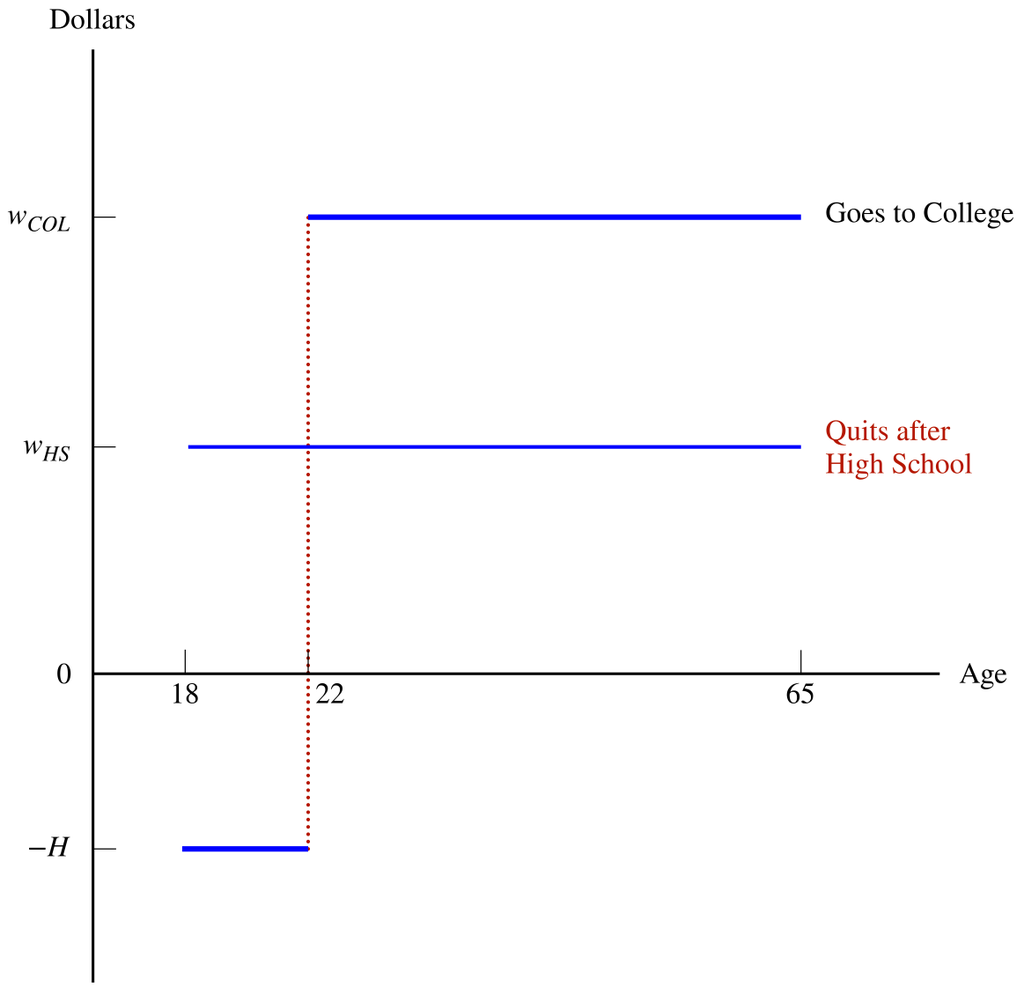

## What Is the Wage-Schooling Locus?

- The **wage-schooling locus** shows the salary a particular worker would earn at each level of schooling.
- **Three key properties**:
- It is **upward sloping**: more schooling → higher wages.
- The **slope** at any point gives the **percentage increase in earnings** from one more year of school.
- It is **concave**: there are **diminishing returns** to schooling — the 13th year of school raises wages less than the 10th.
- Concavity means the **marginal rate of return to schooling (MRR)** is declining.

## What Is the Wage-Schooling Locus? (Figure)

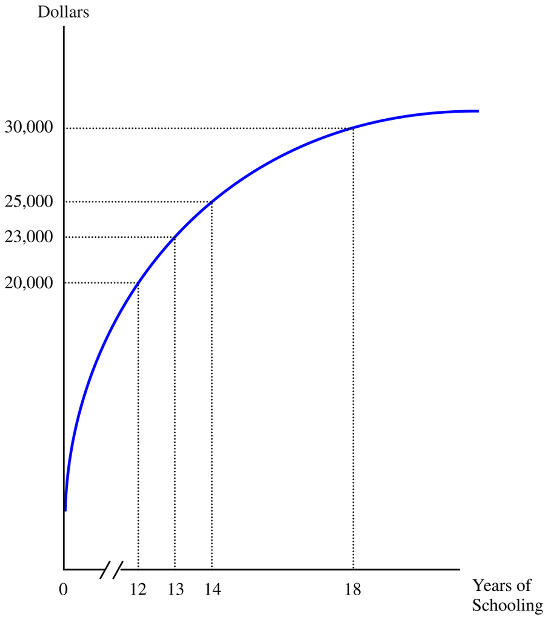

## How Does a Worker Choose How Much Schooling to Get?

- The **marginal rate of return (MRR)** schedule plots the percentage return to each additional year of school — it slopes **downward** due to concavity of the wage-schooling locus.
- A worker maximises the present value of lifetime earnings by going to school until:
  $$\boxed{MRR = r}$$
- The **stopping rule** (Borjas, Eq. 6-9): acquire schooling up to the point where the marginal return equals the rate of discount.
- A worker with discount rate $r$ chooses $s^*$ years of schooling.

## How Does a Worker Choose How Much Schooling to Get? (Figure)

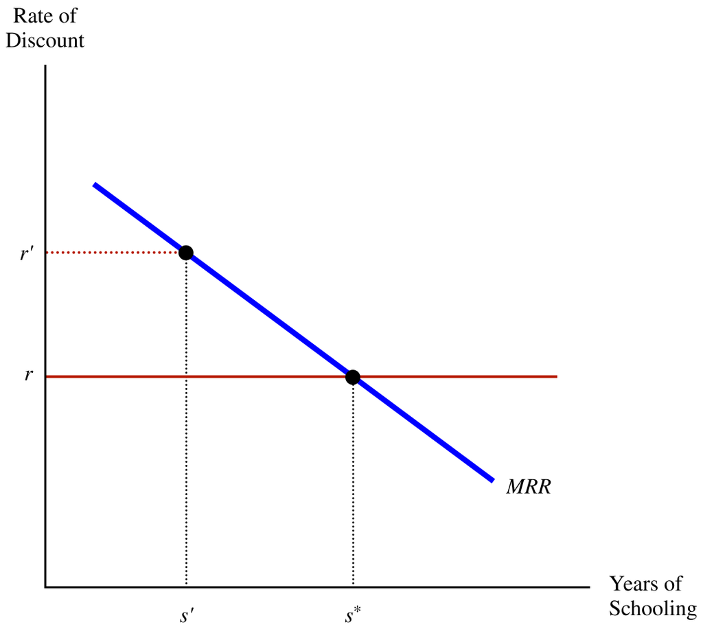

## Workers with Different Discount Rates (Figure)

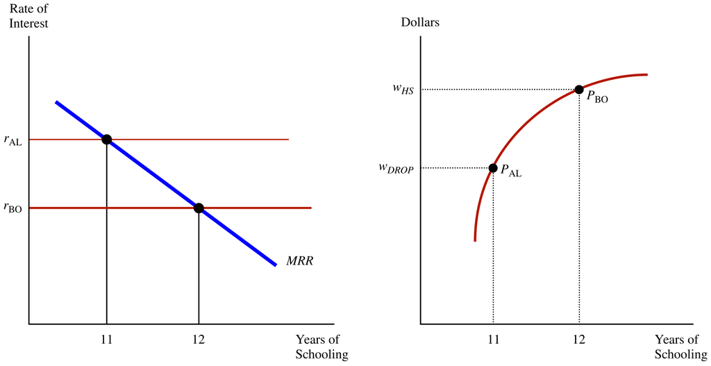

## Workers with Different Abilities (Figure)

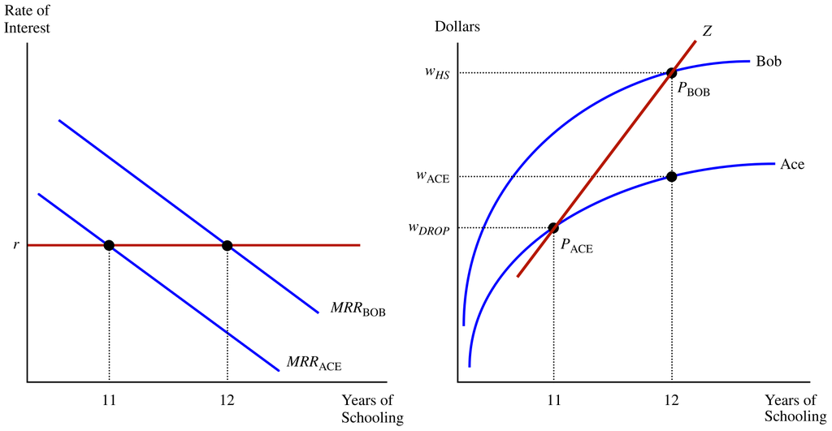

## What Is Ability Bias?

- **Ability bias**: OLS overstates the return to schooling because **unobserved ability** drives both education and wages.
- In a regression of log wages on years of schooling:
  $$\log {\color{#0F6E56}w_i} = a + {\color{#F01928}b} \cdot {\color{#185FA5}s_i} + \text{other variables}$$
- The coefficient ${\color{#F01928}b}$ captures the true return **plus** the ability premium.
- If we could control for ability ${\color{#993C1D}A_i}$:
  $$\log {\color{#0F6E56}w_i} = a + {\color{#F01928}b} \cdot {\color{#185FA5}s_i} + {\color{#993C1D}\alpha} \cdot {\color{#993C1D}A_i} + \text{other variables}$$
  then ${\color{#F01928}b}$ would measure the true return. But ability is typically **unobserved**.

## How Do Twin Studies Address Ability Bias?

- **Identical twins** share the same genetic endowment ($A_i = A_j$), so differencing within twin pairs eliminates the ability term:
  $$\Delta \log {\color{#0F6E56}w_j} = {\color{#F01928}b} \cdot \Delta {\color{#185FA5}s_j} + \text{other variables}$$
- This removes the **genetic component** of ability bias (Borjas, Eq. 6-12).
- Twin study estimates range from **3% to 15%** annual return per year of schooling — a wide range.
- **Problems**: measurement error in self-reported schooling (biases $b$ → zero); twins may differ in non-genetic traits (motivation, health).

## How Do Instrumental Variables Address Ability Bias?

- **Instrumental variables (IV)**: find an exogenous source of variation in schooling that is **uncorrelated with ability**.
- **Quarter of birth** (Angrist & Krueger 1991): compulsory schooling + school-entry cutoffs → Q1-born drop out earlier. IV estimate: ~7.5%/year.
- **French riots of 1968**: easier admission → exogenous education increase for one cohort. IV estimate: ~14%/year.
- **Compulsory schooling laws**: changes in minimum school-leaving age provide exogenous variation across cohorts.

## The Problem: Ability Confounds the Schooling–Wage Link

[figure not shown]

## The IV Solution: Use Only the “Clean” Variation

[figure not shown]

## The Logic of IV: Strip Away Ability, Keep Only the Nudge

- **The problem**: $\log({\color{#0F6E56}w}) = {\color{#F01928}\beta} \cdot {\color{#185FA5}s} + {\color{#993C1D}\gamma} \cdot {\color{#993C1D}A} + \varepsilon$ — but ${\color{#993C1D}A}$ is **unobserved**
- **The instrument** ${\color{#534AB7}Z}$ must satisfy:
- **Relevance**: ${\color{#534AB7}Z}$ shifts ${\color{#185FA5}s}$
- **Exclusion**: ${\color{#534AB7}Z}$ affects ${\color{#0F6E56}w}$ **only through** ${\color{#185FA5}s}$ — no direct path, no correlation with ${\color{#993C1D}A}$
- **2SLS mechanics**:
- Stage 1: $s = \pi Z + v$ → predicted $\hat{s}$ contains only **ability-free** variation
- Stage 2: $\log(w) = \beta \; \hat{s} + \varepsilon$ → clean estimate

## Classic Instruments and the Exclusion Restriction

- **Card (1995)**: proximity to a college — geography nudges enrollment, not ability
- **Angrist & Krueger (1991)**: quarter of birth — compulsory schooling cutoffs assign education by birth timing
- **The hard part**: **“uncorrelated with ability” is usually untestable** — you can’t directly verify the exclusion restriction
- IV estimates are only as credible as the **institutional story** about why $Z$ is truly exogenous to unobservables

[figure not shown]

## The Best Instruments for the Mincerian Wage Equation

Controlling for unobserved ability ${\color{#993C1D}A}$ in $\log {\color{#0F6E56}w} = a + {\color{#F01928}b} \cdot {\color{#185FA5}s} + {\color{#993C1D}\gamma A} + \varepsilon$

| Instrument (Z) | Study | Why It Works | OLS | IV | Country |
| --- | --- | --- | --- | --- | --- |
| **Quarter of birth** | Angrist & Krueger (1991) *QJE* | Compulsory schooling + school-entry cutoffs → Q1-born drop out earlier; birth timing ≈ random w.r.t. ability | 7.1% | 7.6–8.9% | US |
| **College proximity** | Card (1995) | Growing up near a 4-year college lowers attendance cost; geography ≠ ability. LATE for credit-constrained compliers. | 7.3% | **13.2%** | US |
| **Compulsory schooling laws** | Harmon & Walker (1995) *AER* | UK raised min. leaving age (14→15 in 1947, 15→16 in 1973); exogenous cohort variation | 6.1% | **15.2%** | UK |
| **School construction (INPRES)** | Duflo (2001) *AER* | 61,000 schools built in high-poverty districts; DiD across districts × birth cohorts | 8.1% | 6.8–10.6% | Indonesia |
| **French riots of 1968** | Maurin & McNally (2008) *JLE* | May 1968 protests → *baccalauréat* exam cancellation → easier university admission for one cohort | 6–7% | **~14%** | France |
| **Identical twins** | Ashenfelter & Krueger (1994) *AER*; Ashenfelter & Rouse (1998) *QJE* | Within-twin differencing eliminates genetic ability; co-twin’s report as IV corrects measurement error | 6.7–8.4% | **12–16%** | US |

- **Pattern** (Card 2001, *Econometrica*): IV estimates typically **≥ OLS** — downward measurement-error bias often exceeds upward ability bias. IV also captures **LATE** for compliers with high marginal returns.

## Does School Quality Affect the Return to Education?

- Not all years of schooling are equal — **school quality** matters.
- Card & Krueger (1992): States with lower **pupil-teacher ratios** (more resources per student) had **higher rates of return** to schooling.
- The **Maimonides Rule** (Angrist & Lavy 1999): In Israel, class sizes are capped at 40. When enrollment crosses a multiple of 40, a new class is added, creating a sharp drop in class size. This natural experiment shows **smaller classes raise test scores**.
- **Tennessee STAR**: Randomised small classes raised test scores. **Dale & Krueger (2002)**: after controlling for *which schools admitted you*, elite college premium ≈ **zero**.

## Does School Quality Affect Returns? (Figure)

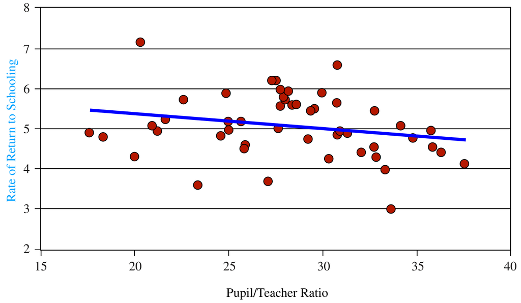

## Can We Test Whether Workers Made the Right Choice?

- The schooling model predicts that each worker selects the level of education that **maximises the present value of lifetime earnings**.
- To test this, we would need to observe the **counterfactual**: what would the college graduate have earned had she *not* gone to college?
- But once a choice is made, the **alternative earnings stream is never observed**.
- Naively comparing college and HS earnings is **contaminated by selection bias**: workers **self-select** into the option that best suits their **comparative advantage**.

## Signaling in the Animal Kingdom

Economists didn’t invent signaling — evolution did.

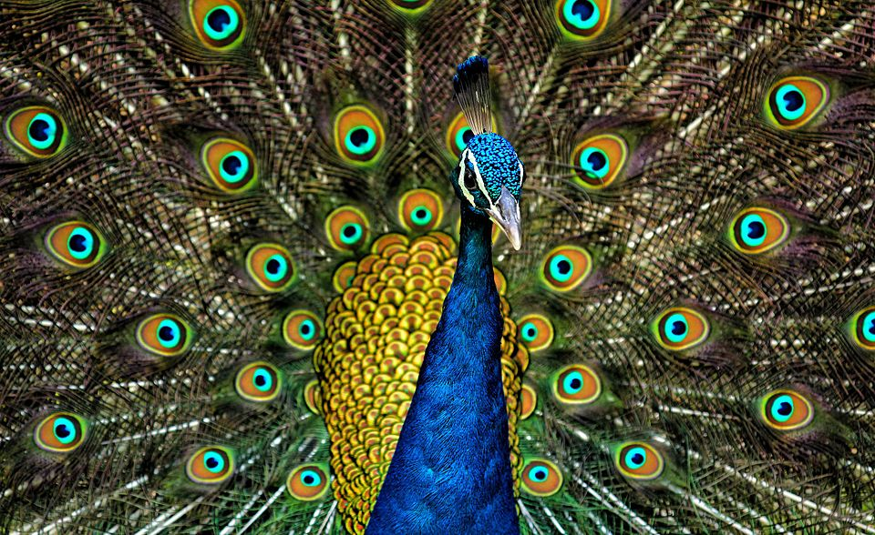

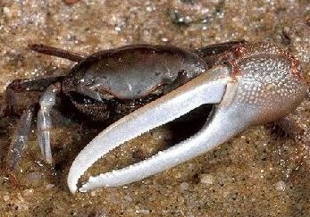

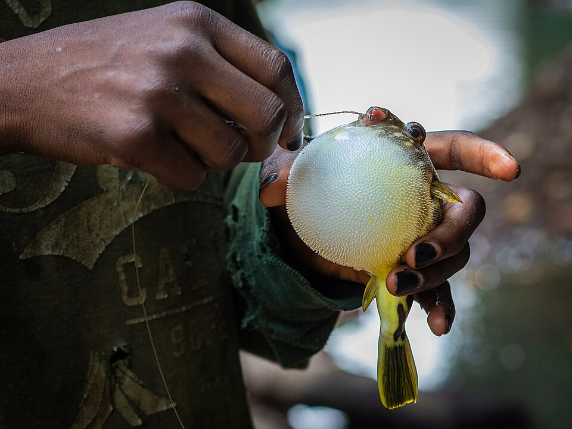

## Why Does the Peacock Work but the Pufferfish Doesn’t?

|  | Peacock | Fiddler crab | Pufferfish |
| --- | --- | --- | --- |
| **Signal** | Giant tail | Regrown big claw | Inflate body |
| **Costly?** | Very (predation risk) | Cheap (hollow muscle) | Cheap |
| **Honest?** | Yes — only fit males survive | No — looks strong, actually weak | Partially — smart predators ignore it |
| **Economics parallel** | Degree from a tough university | Fake degree / diploma mill | Credential inflation (everyone has an MBA) |

- **The pattern**: A signal is credible only when it is **too costly for low-quality types to fake**.
- When the cost collapses → everyone signals → the signal becomes **noise**.
- This is exactly what **Michael Spence (1973)** formalised for the labour market…

## What Is the Signaling Model?

- **Key assumption**: Education does **not** increase a worker’s productivity — it merely reveals the worker’s **innate ability** to employers.
- Workers **know** their own ability, but employers **cannot observe it** directly → **asymmetric information**. Education serves as a **signal** — just like the **peacock’s tail**.
- For a signal to work, it must be **more costly for low-ability workers** to acquire — otherwise everyone would signal (the **pufferfish problem**).
- This gives rise to two possible equilibria: **pooling** and **separating**.

## Signaling at the Movies: The Credential Is Everything

[figure not shown]

[figure not shown]

[figure not shown]

[figure not shown]

- **Catch Me** — fake credentials, zero human capital
- **Suits** — real skills, no degree
- **3 Idiots** — Chatur = signal; Rancho = human capital
- **Hindi Medium** — school name signals, not education quality

## When Human Capital Wins Back

[figure not shown]

Good Will Hunting (1997)

[figure not shown]

Legally Blonde (2001)

[figure not shown]

12th Fail (2023)

- **Good Will Hunting** — raw ability wasted until mentorship unlocks it
- **Legally Blonde** — starts as signal, ends as genuine skill
- **12th Fail** — fails 12th but clears UPSC; exam reveals ability

## What Is a Pooling Equilibrium?

- Suppose employers **cannot distinguish** high-ability and low-ability workers.

| Share of workforce | True productivity |
| --- | --- |
| *q* (low-productivity) | $200,000 |
| (1 − *q*) (high-productivity) | $300,000 |

- $$\text{Average salary} = 300{,}000 - 100{,}000 \cdot q$$
- All workers are paid the **same pooled wage** regardless of ability — high-ability workers are **underpaid**, low-ability workers are **overpaid**.
- High-ability workers have an **incentive to signal** their type by acquiring education, even if education doesn’t increase productivity.

## What Is a Separating Equilibrium?

- Firms announce: **workers with** $\geq y$ years of college get $300K; **workers with** $< y$ years get $200K.
- For this to be a **separating equilibrium**, two conditions must hold:
- **Low-productivity workers must not want to get** $y$ years of college:
- Therefore, the low-productivity worker will not attend college if:
  $$\$200{,}000 > \$300{,}000 - (\$25{,}001 \times y)$$
- Solving: $25{,}001y > 100{,}000$ → $y > 3.999$ years.
- **Rule of thumb**: if the firm requires more than 4 years of college, no low-productivity worker will ever attend — it is just too expensive.

## What Is a Separating Equilibrium?

- **High-productivity workers must want to get** $y$ years of college:
- The net salary without college is $\$200{,}000$. Cost for high-ability: $\$20{,}000 \times y$.
- Therefore, high-productivity workers get $y$ years whenever:
  $$\$200{,}000 < \$300{,}000 - (\$20{,}000 \times y)$$
- Solving: $20{,}000y < 100{,}000$ → $y < 5$ years.
- **Separating equilibrium exists** for $4 < y < 5$ years (Borjas, Eq. 6-23).

## Separating Equilibrium (Figure)

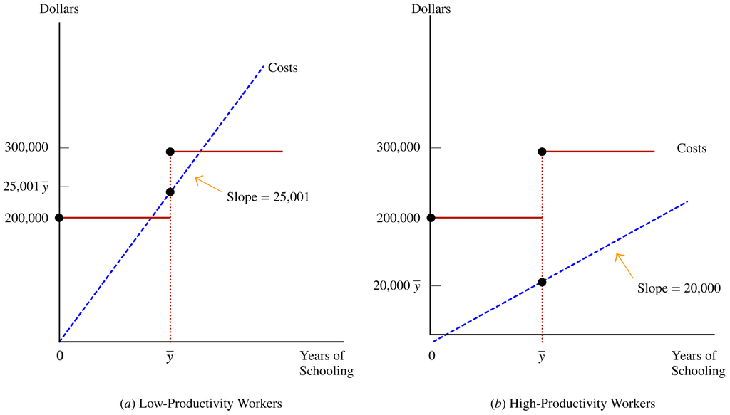

## Which Threshold Survives Competition?

- Any threshold in the range $4 < y < 5$ generates a valid separating equilibrium — firms could pick 4.333, 4.5, or 4.997 years and both types would sort themselves accordingly.
- But **high-productivity workers prefer the lowest threshold**: all firms pay the same $300K, so workers gain nothing from extra years beyond the minimum required.
- **Competitive pressure** eliminates higher thresholds — firms offering 4.333 years lose talent to firms requiring only 4 years, since both pay $300K.
- The **competitive equilibrium** converges to the **smallest feasible threshold**: a **4-year college diploma** becomes the separating device.

## What Are the Implications of the Signaling Model?

- For schooling to act as a signal, schooling must be **more costly for low-ability workers** than for high-ability workers.
- **Private returns**: Even if education only signals, individual workers still earn more by getting educated → the private return to schooling is **positive**.
- **Social returns**: If education is *purely* a signal, the social return could be **zero** — but sorting itself has value, so the social return is likely positive even in the signaling model.
- **Reality**: Education is probably **both** — partly human capital (raises productivity) and partly signal (sorts workers). The debate is about the **relative magnitudes**.

## Review — Human Capital Basics

- Education is an **investment**: workers weigh current costs (tuition + foregone earnings) against future returns.
- More education → higher LFP, lower unemployment, higher earnings — monotonically, across all groups.
- Four views of why: Becker (productivity), Schultz (adaptability), Bowles-Gintis (compliance), Spence (signal of innate ability).

## Review — The Schooling Model

- Total cost of college = direct costs ($H$) + opportunity cost (foregone $w_{HS}$ for 4 years).
- Stopping rule: invest in schooling until **MRR = r** (marginal return equals discount rate).
- The wage-schooling locus is concave — diminishing returns mean each extra year adds less.
- If workers differ only in patience, the observed education-earnings slope correctly identifies the causal return.

## Review — Estimating Returns

- Twin studies difference out genetic ability; measurement error in self-reported schooling biases the estimate back down.
- IV uses exogenous shocks to schooling (quarter of birth, college proximity, compulsory laws, school construction).
- IV estimates are typically **≥ OLS** — measurement-error bias (downward) often exceeds ability bias (upward).
- School quality matters (smaller classes → higher scores), but elite college premium ≈ zero after controlling for selection (Dale-Krueger).

## Review — Signaling

- In the signaling model, education **reveals** ability rather than raising productivity — the peacock’s tail, not a training programme.
- Separating equilibrium requires the **single-crossing property**: schooling must be cheaper for high-ability types so low types cannot mimic.
- Separating range: $4 < y < 5$ years; competition drives firms to the minimum threshold (the 4-year degree).
- Private returns are positive even under pure signaling; social returns may be near zero (credential arms race).
- Reality: education is probably both human capital and signal — the debate is about relative magnitudes.